# 第3章 資料視覺化與洞察(ggplot2)

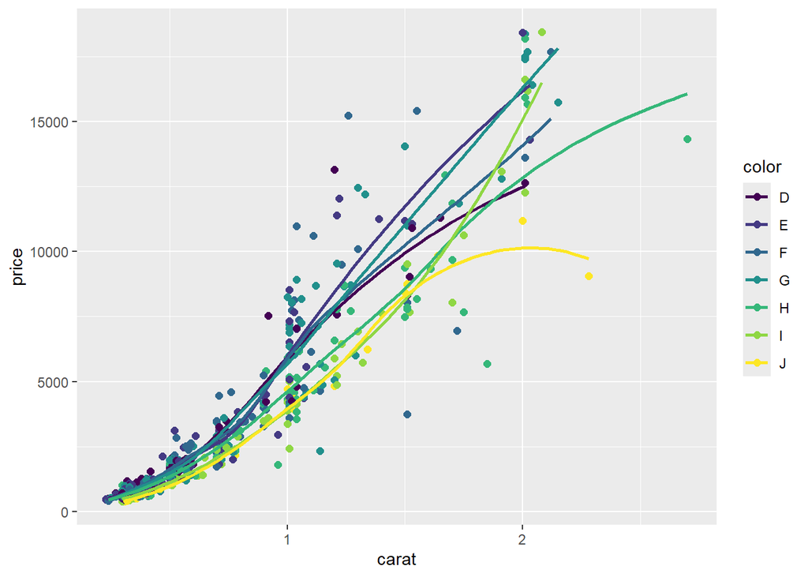

```r
# ggplot: 散佈圖 + 群組loess (Local Polynomial Regression Fitting)
# LOESS = Local Polynomial Regression Fitting 局部多項式迴歸擬合（也常稱為 區域多項式迴歸）
# 它是一種非參數（non-parametric）迴歸方法，主要用來在散佈圖中找出資料的非線性趨勢。
# 與一般的線性迴歸：y = β₀ + β₁x 不同，LOESS 不要求整體資料必須符合一條直線特性。
# LOESS = 局部資料 + 加權 + 多項式迴歸 + 平滑曲線
# ?loess
ggplot(dsmall, aes(carat, price, group=color)) +
  geom_point(aes(color=color), size=2) +
  geom_smooth(aes(color=color), method="loess", se=FALSE)
```

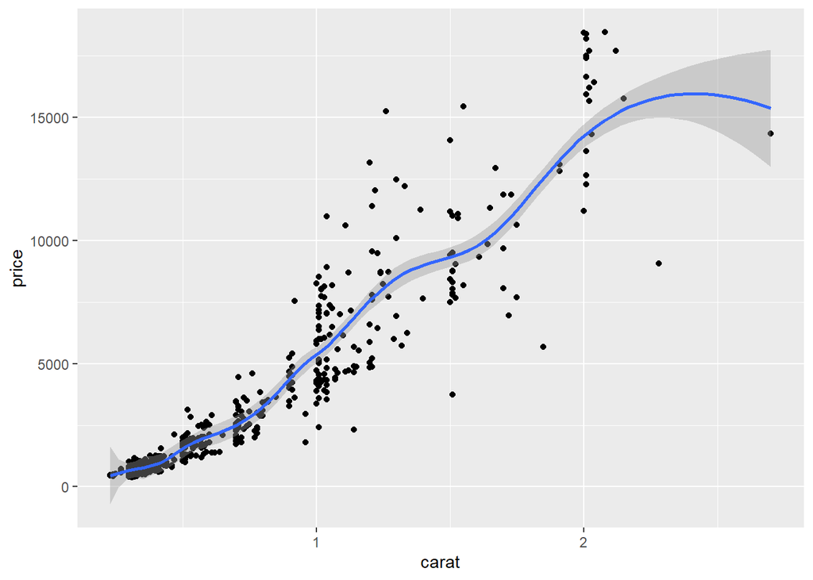

```r
# ggplot: 散佈圖 + span
ggplot(dsmall, aes(carat, price)) +
  geom_point() +
  geom_smooth(span = 0.3) # span 數值愈小，曲線愈彎曲。
```

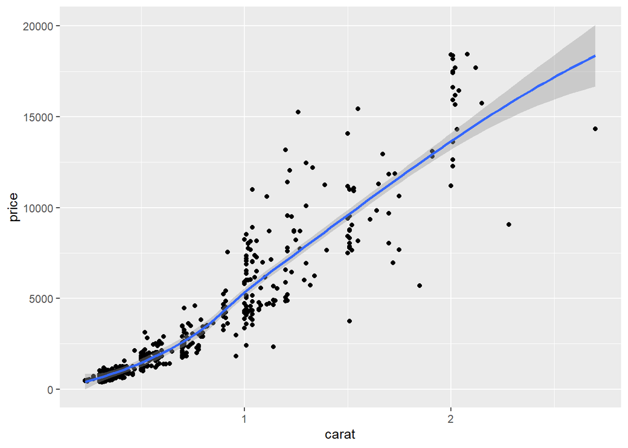

```r
# ggplot: 散佈圖 + span
ggplot(dsmall, aes(carat, price)) +
  geom_point() +
  geom_smooth(span = 0.8)
```

## 箱型圖

- 箱型圖（Boxplot / Box-and-Whisker Plot）是一種用來快速了解數值資料分布情形的統計圖形。
- 特色是利用中位數、四分位數與離群值，在一張圖中呈現資料的分布、集中程度、變異程度與異常值。
- 箱子的大小 IQR（Interquartile Range，四分位距）$IQR = Q_3 − Q_1$
- 離群值（Outliers）通常以超過箱體範圍：$Q_1 − 1.5 \times IQR$ 到 $Q_3 + 1.5 \times IQR$ 作為離群值的基準。

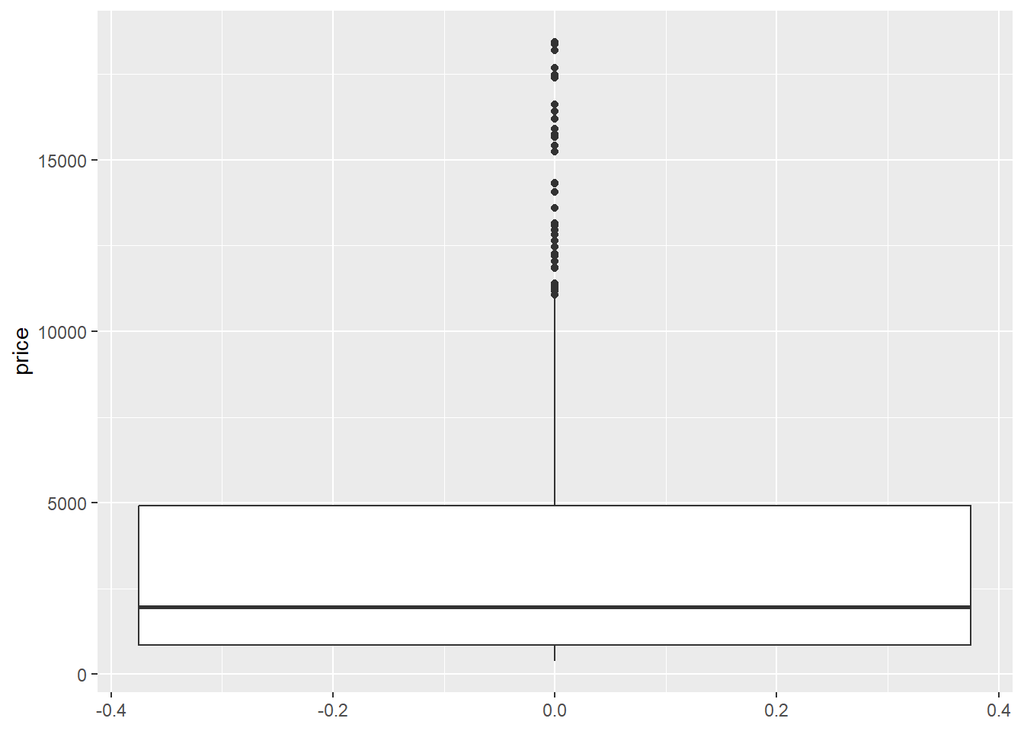

```r
# price 變數的整體分佈
ggplot(dsmall, aes(y = price)) +
  geom_boxplot()
```

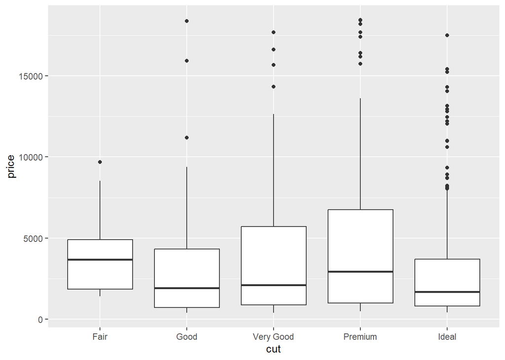

```r
# 依 cut 為組紅的 price 箱型圖
# Fair < Good < Very Good < Premium < Ideal, 愈右側水準表示切割品質愈好.
ggplot(dsmall, aes(x = cut, y = price)) +
  geom_boxplot()
```

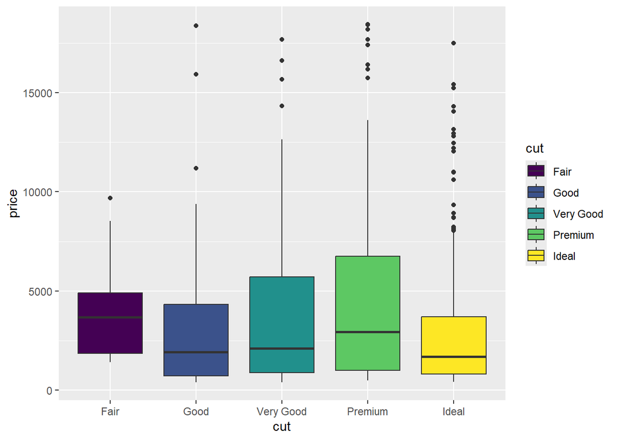

```r
# 依 cut 為群組的 price 箱型圖
# 依 cut 為群組會有不同填色
ggplot(dsmall, aes(x = cut, y = price)) +
  geom_boxplot(aes(fill = cut))
```

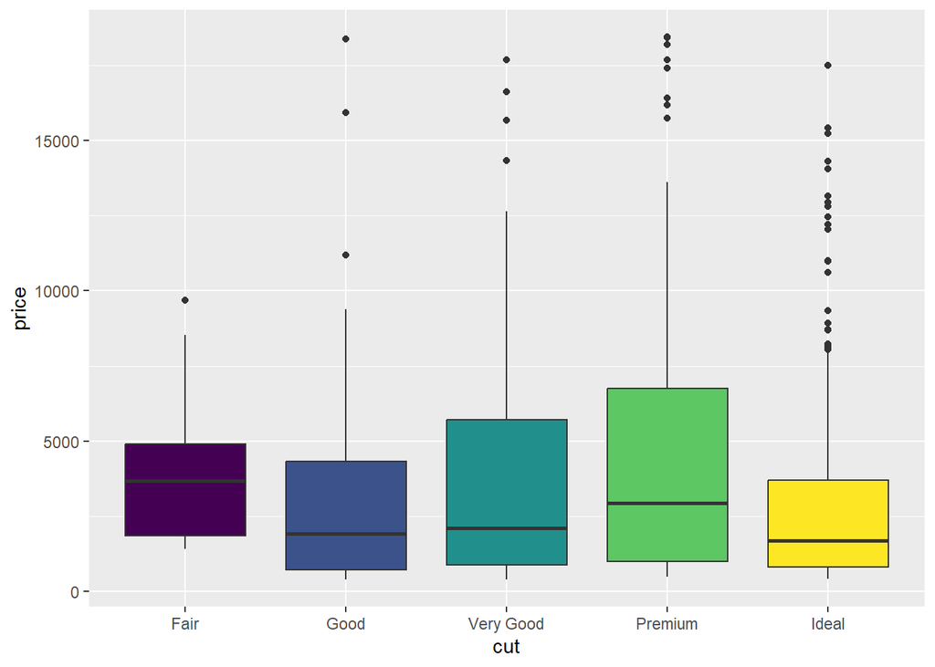

```r
# 省略圖例 show.legend = FALSE
ggplot(dsmall, aes(x = cut, y = price)) +
  geom_boxplot(aes(fill = cut), show.legend = FALSE)
```

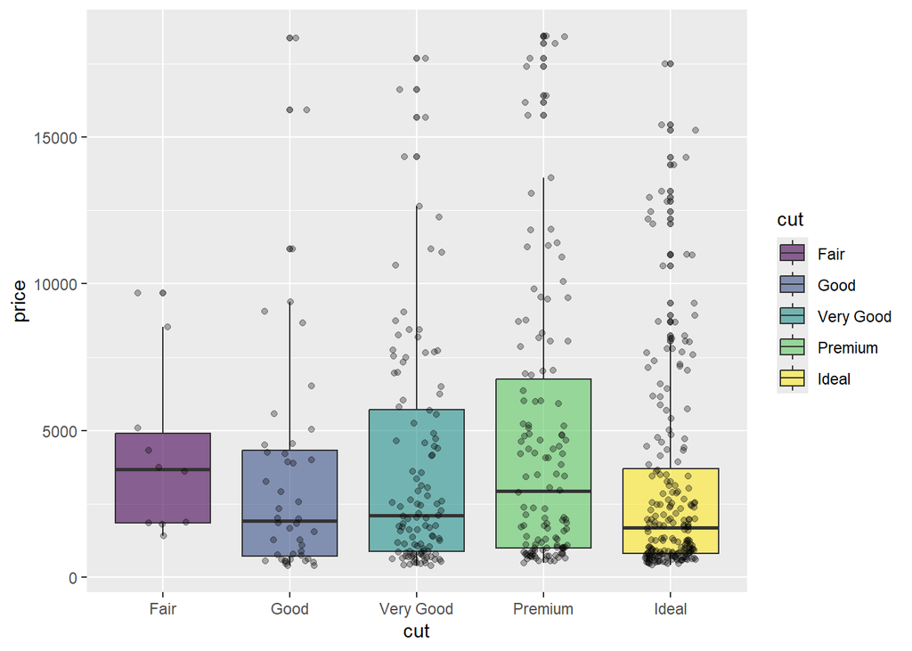

```r
# 加入原始資料點 geom_jitter
ggplot(dsmall, aes(x = cut, y = price)) +
  geom_boxplot(aes(fill = cut), alpha = 0.6) +
  geom_jitter(
    width = 0.2,
    alpha = 0.3
  )
```

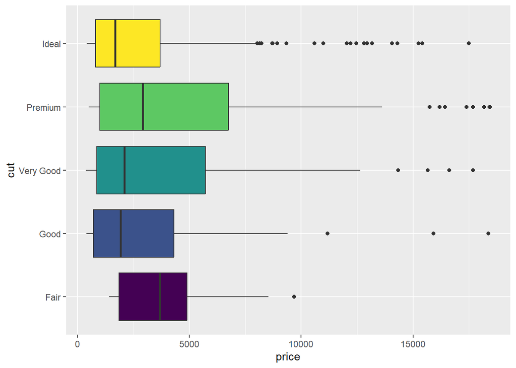

```r
# 水平箱型圖
ggplot(dsmall, aes(x = price, y = cut)) +
  geom_boxplot(aes(fill = cut), show.legend = FALSE)
```

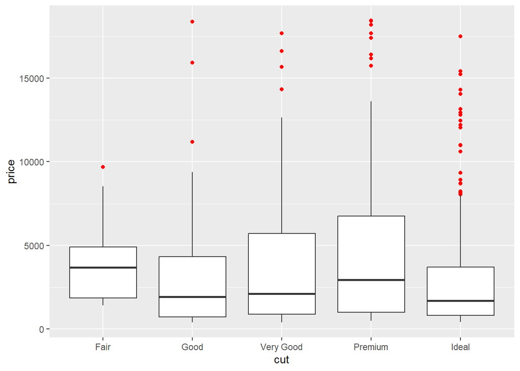

```r
# 標示離群值
ggplot(dsmall, aes(x = cut, y = price)) +
  geom_boxplot(outlier.colour = "red",
               outlier.shape = 16)
```

## ggplot2 雙軸(Y1,Y2)繪圖

參考: http://rwepa.blogspot.com/2017/09/ggplot2-2y-packagelist.html

## ggplot2-新增數學式-以迴歸分析模型為例

參考: http://rwepa.blogspot.com/2020/09/ggplot2-equation.html

## 弦圖 (Chord diagram)

參考: http://rwepa.blogspot.com/2019/10/chord-diagram.html

# 🌸 3.3 分面與分組比較(facet、color/fill)

```r
# 參考 3.1, 3.2
```

# 🌸 3.4 圖表標註與故事化呈現(標題、註解、重點標示)

```r
# 參考 3.1, 3.2
```

# 🌸 3.5 練習：產出一頁「關鍵洞察」圖表集

```r
# 學員練習
```

## 案例-ggplot2於製程不良率視覺化應用

ChatGPT: 模擬10萬筆台積電公司製程不良率資料, 資料至少包括年月日時間, location, 批號, 生產量, 使用 dplyr, ggplot2 套件進行資料預處理分析, 視覺化分析.

```r
# 載入套件
library(dplyr)
```

```r
library(ggplot2)
```

```r
# 設定資料集大小
datasize <- 100000

# 亂數種子
set.seed(123)

# 建立模擬製程資料
df <- data.frame(
  id = 1:datasize,
  year = sample(2018:2023, size = datasize, replace = TRUE),
  month = sample(1:12, size = datasize, replace = TRUE),
  day = sample(1:31, size = datasize, replace = TRUE),
  location = sample(c("台中", "高雄", "新竹"), size = datasize, replace = TRUE),
  batch_number = paste0("Batch", sample(1:10, size = datasize, replace = TRUE)),
  production_volume = runif(datasize, min = 0.001, max = 100),
  defect_rate = rnorm(datasize, mean = 0.05, sd = 0.01)
)

# 轉換為 tbl_df
df <- tibble::as_tibble(df)

# 類別
class(df) # "tbl_df" "tbl" "data.frame"
```

```
## [1] "tbl_df"     "tbl"        "data.frame"
```

```r
df
```

| id | year | month | day | location | batch_number | production_volume | defect_rate |
| --- | --- | --- | --- | --- | --- | --- | --- |
| 1 | 2020 | 5 | 21 | 台中 | Batch3 | 98.25845114 | 0.05838296 |
| 2 | 2023 | 9 | 6 | 台中 | Batch2 | 8.40683659 | 0.04089820 |
| 3 | 2020 | 2 | 10 | 新竹 | Batch6 | 41.50463473 | 0.06123493 |
| 4 | 2019 | 6 | 3 | 高雄 | Batch8 | 16.07115708 | 0.05108935 |
| 5 | 2019 | 3 | 19 | 新竹 | Batch7 | 69.59188768 | 0.05094025 |
| 6 | 2023 | 11 | 9 | 台中 | Batch10 | 15.66804321 | 0.04332788 |
| 7 | 2020 | 4 | 5 | 台中 | Batch2 | 68.00116651 | 0.03707225 |
| 8 | 2022 | 5 | 19 | 新竹 | Batch2 | 70.39974877 | 0.04257171 |
| 9 | 2021 | 6 | 10 | 台中 | Batch1 | 95.24182343 | 0.02250176 |
| 10 | 2023 | 3 | 2 | 台中 | Batch1 | 74.47126244 | 0.04752819 |

[output cut: 9990 more lines]

```r
# 新增製程日期變數
df <- df %>%
  mutate(process_date = as.Date(paste0(year, "/", month, "/", day)))

# 計算每日平均不良率
df_summary <- df %>%
  group_by(process_date) %>%
  summarise(AvgDefectRate = mean(defect_rate))

# 刪除NA值
df_summary <- df_summary %>%
  na.omit()

# 資料結構
str(df_summary)
```

```
## tibble [2,191 × 2] (S3: tbl_df/tbl/data.frame)
##  $ process_date : Date[1:2191], format: "2018-01-01" "2018-01-02" ...
##  $ AvgDefectRate: num [1:2191] 0.0503 0.0492 0.0503 0.0503 0.0514 ...
##  - attr(*, "na.action")= 'omit' Named int 2192
##   ..- attr(*, "names")= chr "2192"
```

```r
# 資料摘要
summary(df_summary)
```

```
##   process_date        AvgDefectRate
##  Min.   :2018-01-01   Min.   :0.04381
##  1st Qu.:2019-07-02   1st Qu.:0.04895
##  Median :2020-12-31   Median :0.04996
##  Mean   :2020-12-31   Mean   :0.04995
##  3rd Qu.:2022-07-01   3rd Qu.:0.05098
##  Max.   :2023-12-31   Max.   :0.05534
```

```r
# 前6筆資料
head(df_summary)
```

| process_date | AvgDefectRate |
| --- | --- |
| 2018-01-01 | 0.05034817 |
| 2018-01-02 | 0.04922784 |
| 2018-01-03 | 0.05030272 |
| 2018-01-04 | 0.05034327 |
| 2018-01-05 | 0.05139282 |
| 2018-01-06 | 0.04740514 |

```r
# 後6筆資料
tail(df_summary)
```

| process_date | AvgDefectRate |
| --- | --- |
| 2023-12-26 | 0.05209694 |
| 2023-12-27 | 0.04987737 |
| 2023-12-28 | 0.05163465 |
| 2023-12-29 | 0.04846340 |
| 2023-12-30 | 0.05067375 |
| 2023-12-31 | 0.05123095 |

```r
# 顯示資料
df_summary
```

| process_date | AvgDefectRate |
| --- | --- |
| 2018-01-01 | 0.05034817 |
| 2018-01-02 | 0.04922784 |
| 2018-01-03 | 0.05030272 |
| 2018-01-04 | 0.05034327 |
| 2018-01-05 | 0.05139282 |
| 2018-01-06 | 0.04740514 |
| 2018-01-07 | 0.05123079 |
| 2018-01-08 | 0.05157231 |
| 2018-01-09 | 0.04623934 |
| 2018-01-10 | 0.04822560 |

[output cut: 2181 more lines]

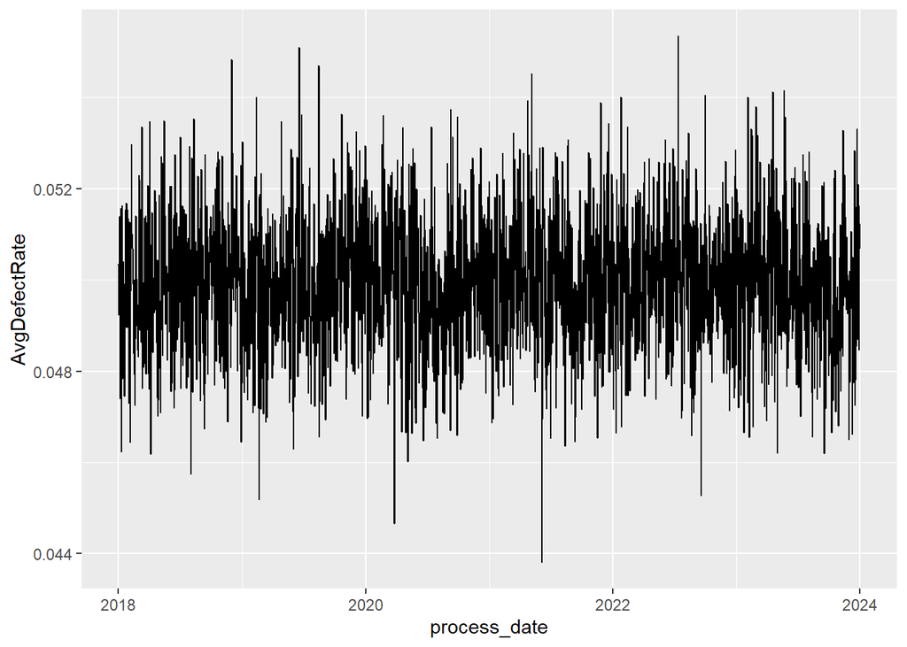

```r
# 使用ggplot2 資料視覺化
ggplot(df_summary, aes(x = process_date, y = AvgDefectRate)) +
  geom_line()
```

```r
# 發現什麼樣式 (patterns) --> NONE
# Try: 優化視覺化結果, 加入平均線
```

```r
# Try: facet_wrap_year
```

```r
# Try: facet_wrap_month
```

```r
# Try: facet_wrap_location
```

## 案例-ggplot2於高速公路案例

- https://rwepa.blogspot.com/2019/05/highway.html